# Data Wrangling Report

Aadrika Singh

## Load all required packages

```r
library(ggplot2)
library(caret)
library(tidyr)
library(Hmisc)
library(dplyr)
library(ggthemes)
```

## Importing dataset

The telecom company’s dataset was imported as a data frame for churn analysis. The dataset includes several attributes (numerical as well as categorical) that contain information about the customers, and an attribute that specifies whether the customer churned or not.

```r
# Reading the dataset ; reading all blanks as NA
telco <- as.data.frame(read.delim("Dataset/orange_small_train.data", na.strings=c("","NA"), header=TRUE, sep="\t", fill=TRUE))

# Add the variable *churn* as a new column
telco$churn <- as.factor(read.table("Dataset/orange_small_train_churn.txt")$V1)
```

Looking at the structure of the dataset:

```r
# Dimensions of the dataset
dim(telco)
```

```
## [1] 50000   231
```

```r
# First 6 rows of some of the columns
head(tbl_df(telco))
```

```
## # A tibble: 6 x 231
##    Var1  Var2  Var3  Var4  Var5  Var6  Var7  Var8  Var9 Var10 Var11 Var12
##   <int> <int> <int> <int> <int> <int> <int> <lgl> <int> <dbl> <int> <int>
## 1    NA    NA    NA    NA    NA  1526     7    NA    NA    NA    NA    NA
## 2    NA    NA    NA    NA    NA   525     0    NA    NA    NA    NA    NA
## 3    NA    NA    NA    NA    NA  5236     7    NA    NA    NA    NA    NA
## 4    NA    NA    NA    NA    NA    NA     0    NA    NA    NA    NA    NA
## 5    NA    NA    NA    NA    NA  1029     7    NA    NA    NA    NA    NA
## 6    NA    NA    NA    NA    NA   658     7    NA    NA    NA    NA    NA
## # ... with 219 more variables: Var13 <int>, Var14 <int>, Var15 <lgl>,
## #   Var16 <dbl>, Var17 <int>, Var18 <int>, Var19 <int>, Var20 <lgl>,
## #   Var21 <int>, Var22 <int>, Var23 <int>, Var24 <int>, Var25 <int>,
## #   Var26 <int>, Var27 <int>, Var28 <dbl>, Var29 <int>, Var30 <int>,
## #   Var31 <lgl>, Var32 <lgl>, Var33 <dbl>, Var34 <int>, Var35 <int>,
## #   Var36 <int>, Var37 <int>, Var38 <int>, Var39 <lgl>, Var40 <int>,
## #   Var41 <int>, Var42 <lgl>, Var43 <int>, Var44 <int>, Var45 <dbl>,
## #   Var46 <int>, Var47 <int>, Var48 <lgl>, Var49 <int>, Var50 <int>,
## #   Var51 <dbl>, Var52 <lgl>, Var53 <dbl>, Var54 <int>, Var55 <lgl>,
## #   Var56 <int>, Var57 <dbl>, Var58 <int>, Var59 <dbl>, Var60 <int>,
## #   Var61 <int>, Var62 <int>, Var63 <int>, Var64 <dbl>, Var65 <int>,
## #   Var66 <int>, Var67 <int>, Var68 <int>, Var69 <dbl>, Var70 <int>,
## #   Var71 <int>, Var72 <int>, Var73 <int>, Var74 <int>, Var75 <int>,
## #   Var76 <int>, Var77 <int>, Var78 <int>, Var79 <lgl>, Var80 <int>,
## #   Var81 <dbl>, Var82 <int>, Var83 <int>, Var84 <int>, Var85 <int>,
## #   Var86 <int>, Var87 <int>, Var88 <int>, Var89 <int>, Var90 <int>,
## #   Var91 <int>, Var92 <int>, Var93 <int>, Var94 <int>, Var95 <int>,
## #   Var96 <int>, Var97 <int>, Var98 <int>, Var99 <int>, Var100 <int>,
## #   Var101 <int>, Var102 <dbl>, Var103 <int>, Var104 <int>, Var105 <int>,
## #   Var106 <int>, Var107 <int>, Var108 <int>, Var109 <int>, Var110 <int>,
## #   Var111 <dbl>, Var112 <int>, ...
```

There are *50,000* observations of *230* variables in the dataset, from which selected input features will be used to predict the outcome or 231st variable **churn**. From the dataset description, it is known that the first *190* variables are **numerical** and the rest of the *40* are **categorical**.

## Cleaning the dataset

As observed, there are a lot of *missing values* in the dataset. To tackle this situation, the proportion of missing values in the columns is observed, as the first step.

```r
# Looking at the proportion of missing values in the remaining columns
checkNA <- sapply(X = telco, FUN = function(x){sum(is.na(x))/nrow(telco)})
```

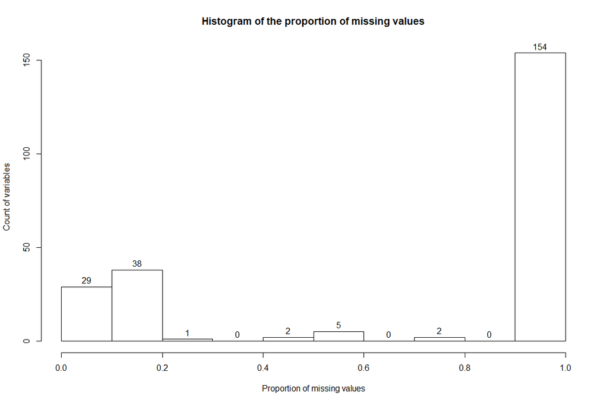

```r
# Plotting a histogram of the proportion of missing values
hist(checkNA,
     main = paste ("Histogram of the proportion of missing values"),
     xlab = "Proportion of missing values",
     ylab = "Count of variables",
     labels = TRUE)
```

Based on the observations from the histogram, the columns where more than 20% of the data is missing, will be removed (most of the columns have more than 90% missing data, and otherwise, there are not many variables with missing values between 20% - 80%), as these variables will not contribute much towards the final goal of prediction.

```r
# Removing the columns which have more than 20% NA values
telco <- telco[, checkNA <= 0.2]
```

```r
# Dimensions of the resulting dataset
dim(telco)
```

```
## [1] 50000    67
```

The dataset now has only *67* variables, all of which have **less than 20%** missing data.

Removing variables with near-zero variance (such as columns having a unique value), as they may not be useful for discriminating classes.

```r
# Get indices of columns with low variance
badCols <- nearZeroVar(telco)
```

```r
# Fraction of the total columns that have near-zero variance
print(paste("Fraction of nearZeroVar columns:", round(length(badCols)/length(telco),4)))
```

```
## [1] "Fraction of nearZeroVar columns: 0.1493"
```

```r
# Remove columns from dataset
telco <- telco[, -badCols]
```

```r
# Dimensions of the resulting dataset
dim(telco)
```

```
## [1] 50000    57
```

The dataset now has *57* variables.

```r
# Renaming the column names to be in proper order
names(telco)[1:56] <- paste("V", 1:56, sep = "")

# Replacing -1 with 0 for churn variable
levels(telco$churn)[telco$churn == "-1"] <- "0"

# Relabel the churn variable as No/Yes instead of 0/1
telco$churn <- factor(telco$churn, levels=c('0', '1'),
  labels=c('No', 'Yes'))
```

## Dealing with missing data

Since missing data values can create problems for analyzing data and creating predictive models, they need to be treated. Imputation is the process for substituting missing data. Simple/single imputation methods include replacing the missing value with the mean/median/mode of the variable. However, creating multiple imputations as compared to a single imputation (such as mean) takes care of uncertainty in missing values.

*Hmisc* package will be used for imputing the missing values for **numerical variables**. It allows mean imputation using additive regression, bootstrapping, and predictive mean matching. In bootstrapping, different bootstrap resamples are used for each of multiple imputations. Then, a flexible additive model (non parametric regression method) is fitted on samples taken with replacements from original data and missing values (acts as dependent variable) are predicted using non-missing values (independent variable).Then, it uses predictive mean matching (default) to impute missing values.

The variables that have no missing values, or are heavily skewed, have been excluded, to facilitate the imputation to run. For the variables that are excluded from the previous step, median imputation will be used to fill in the missing values.

For **categorical variables**, all the NA values will be replaced by another factor level called “Unknown”.

```r
# Set Seed
set.seed(144)

# Identify the variables that have no missing values, to remove them from the imputation
checkNA <- sapply(X = telco, FUN = function(x){sum(is.na(x))/nrow(telco)})
```

```r
# Names of the variables that have no missing values
names(telco[, checkNA == 0])
```

```
##  [1] "V11"   "V13"   "V21"   "V34"   "V36"   "V40"   "V43"   "V45"
##  [9] "V46"   "V47"   "V50"   "V51"   "V52"   "V54"   "V55"   "V56"
## [17] "churn"
```

```r
# Analyze summary for numerical variables - I
summary(subset(telco, select = colnames(telco)[1:11]))
```

```
##        V1               V2                V3               V4
##  Min.   :     0   Min.   :  0.000   Min.   :     0   Min.   :    0.0
##  1st Qu.:   518   1st Qu.:  0.000   1st Qu.:     0   1st Qu.:  112.0
##  Median :   861   Median :  7.000   Median :   232   Median :  144.0
##  Mean   :  1326   Mean   :  6.809   Mean   :  1250   Mean   :  234.5
##  3rd Qu.:  1428   3rd Qu.:  7.000   3rd Qu.:  1604   3rd Qu.:  228.0
##  Max.   :131761   Max.   :140.000   Max.   :197872   Max.   :36272.0
##  NA's   :5529     NA's   :5539      NA's   :5539     NA's   :5529
##        V5                V6                V7                 V8
##  Min.   :    0.0   Min.   :  0.000   Min.   :    0.00   Min.   : -66.88
##  1st Qu.:  135.0   1st Qu.:  0.000   1st Qu.:   16.00   1st Qu.: 166.56
##  Median :  180.0   Median :  2.000   Median :   48.00   Median : 220.08
##  Mean   :  290.2   Mean   :  4.508   Mean   :   96.83   Mean   : 224.51
##  3rd Qu.:  285.0   3rd Qu.:  6.000   3rd Qu.:  112.00   3rd Qu.: 266.40
##  Max.   :45340.0   Max.   :494.000   Max.   :13168.00   Max.   :5158.56
##  NA's   :5009      NA's   :7230      NA's   :5009       NA's   :5011
##        V9               V10                V11
##  Min.   :  0.000   Min.   :       0   Min.   :0.000214
##  1st Qu.:  0.000   1st Qu.:    7794   1st Qu.:1.743164
##  Median :  0.000   Median : 1290246   Median :3.514740
##  Mean   :  0.717   Mean   : 2579107   Mean   :3.512311
##  3rd Qu.:  0.000   3rd Qu.: 4570944   3rd Qu.:5.264741
##  Max.   :110.000   Max.   :18846900   Max.   :7.000000
##  NA's   :5009      NA's   :5009
```

```r
# Analyze summary for numerical variables - II
summary(subset(telco, select = colnames(telco)[12:22]))
```

```
##       V12              V13              V14                V15
##  Min.   :  9.00   Min.   :  4.00   Min.   :     0.0   Min.   :       0
##  1st Qu.:  9.00   1st Qu.: 24.00   1st Qu.:     0.0   1st Qu.:   89360
##  Median :  9.00   Median : 52.00   Median :     7.0   Median :  882000
##  Mean   : 14.87   Mean   : 66.64   Mean   :   103.7   Mean   : 1490154
##  3rd Qu.: 18.00   3rd Qu.:102.00   3rd Qu.:    84.0   3rd Qu.: 2309884
##  Max.   :180.00   Max.   :264.00   Max.   :142156.0   Max.   :19353600
##  NA's   :5539                      NA's   :5539       NA's   :5009
##       V16               V17               V18                V19
##  Min.   :      0   Min.   :   0.00   Min.   :   0.000   Min.   :   0.00
##  1st Qu.:  16357   1st Qu.:   0.00   1st Qu.:   0.000   1st Qu.:  24.00
##  Median :  73523   Median :  10.00   Median :   4.000   Median :  32.00
##  Mean   : 103084   Mean   :  20.02   Mean   :   8.461   Mean   :  60.89
##  3rd Qu.: 181977   3rd Qu.:  25.00   3rd Qu.:  10.000   3rd Qu.:  56.00
##  Max.   :1814403   Max.   :6335.00   Max.   :1178.000   Max.   :7456.00
##  NA's   :5529      NA's   :5009      NA's   :5009       NA's   :7230
##       V20                V21                V22
##  Min.   :    0.00   Min.   :-9803600   Min.   :     0.0
##  1st Qu.:   16.00   1st Qu.: -182715   1st Qu.:   425.0
##  Median :   40.00   Median :   29615   Median :   560.0
##  Mean   :   66.22   Mean   : -153279   Mean   :   916.1
##  3rd Qu.:   72.00   3rd Qu.:  147488   3rd Qu.:   895.0
##  Max.   :10352.00   Max.   : 9932480   Max.   :105060.0
##  NA's   :5009                          NA's   :5529
```

```r
# Analyze summary for numerical variables - III
summary(subset(telco, select = colnames(telco)[23:32]))
```

```
##       V23                V24               V25               V26
##  Min.   :    0.00   Min.   :      0   Min.   :  0.000   Min.   :       0
##  1st Qu.:    6.00   1st Qu.:    234   1st Qu.:  0.000   1st Qu.:  216808
##  Median :   30.00   Median :   6471   Median :  0.000   Median : 1479810
##  Mean   :   60.19   Mean   :  27888   Mean   :  3.525   Mean   : 2273572
##  3rd Qu.:   72.00   3rd Qu.:  31617   3rd Qu.:  0.000   3rd Qu.: 3604725
##  Max.   :13086.00   Max.   :5436045   Max.   :184.000   Max.   :15009900
##  NA's   :5009       NA's   :5539      NA's   :5009      NA's   :5009
##       V27               V28             V29                V30
##  Min.   :      0   Min.   : 0.00   Min.   :       0   Min.   :       0
##  1st Qu.:  29808   1st Qu.: 0.00   1st Qu.:       0   1st Qu.: 1232346
##  Median : 208928   Median : 9.00   Median :   51898   Median : 8131560
##  Mean   : 437340   Mean   :11.73   Mean   :  294921   Mean   : 6181967
##  3rd Qu.: 614884   3rd Qu.:18.00   3rd Qu.:  412113   3rd Qu.:10373380
##  Max.   :5735340   Max.   :81.00   Max.   :16934400   Max.   :13907800
##  NA's   :5009      NA's   :5529    NA's   :7230       NA's   :5009
##       V31              V32
##  Min.   :   0.0   Min.   :       0
##  1st Qu.:  10.0   1st Qu.:       0
##  Median :  22.0   Median :  134622
##  Mean   :  38.8   Mean   :  486078
##  3rd Qu.:  42.0   3rd Qu.:  615900
##  Max.   :4862.0   Max.   :14515200
##  NA's   :5009     NA's   :5009
```

Applying multiple imputation for missing values in numerical variables and adding an “Unknown” factor level which replaces missing values in categorical variables:

```r
# Use imputation
f <- aregImpute(~V1+V2+V3+V4+V5+V6+V7+V8+V10+V14+V15+V16+V17+V18+V19+V20+V22+V23+V24+V26+V27+V28+V29+V30+V31+V32, data = telco, n.impute = 5)

# Get the imputed values
imputed <-impute.transcan(f, data=telco, imputation=1, list.out=TRUE, pr=FALSE, check=FALSE)

# Convert the list to the database
imputed.data <- as.data.frame(do.call(cbind,imputed))

# Arrange the columns accordingly
imputed.data <- imputed.data[, colnames(telco)[c(1,2,3,4,5,6,7,8,10,14,15,16,17,18,19,20,22,23,24,26,27,28,29,30,31,32)], drop = FALSE]

# Update the dataset
for(i in colnames(telco)[c(1,2,3,4,5,6,7,8,10,14,15,16,17,18,19,20,22,23,24,26,27,28,29,30,31,32)]){
 telco[[i]] <- imputed.data[[i]]
}

# Dealing with missing values for categorical variables - adding the level "Unknown"
for(i in colnames(telco)[33:56]){
 levels(telco[[i]]) <- c(levels(telco[[i]]), "Unknown")
 telco[[i]][is.na(telco[[i]])] <- "Unknown"
}

# Drop unused levels
for(i in colnames(telco)[33:56]){
 telco[[i]] <- droplevels(telco[[i]])
}

# Identify the variables that have missing values, to fill the missing values
checkNA <- sapply(X = telco, FUN = function(x){sum(is.na(x))/nrow(telco)})
```

```r
# Names of the variables that have may have missing values
names(telco[, checkNA != 0])
```

```
## [1] "V9"  "V12" "V25"
```

```r
# Function to replace NA values with median of the column
replaceMed <- function(x){ifelse(is.na(x), median(x, na.rm = TRUE), x)}

# Replacing the NA value in the columns with median of the column
for(i in colnames(telco)[c(9,12,25)]){
 telco[[i]] <- replaceMed(telco[[i]])
}

# Ensuring that no variable has a missing value anymore
checkNA <- sapply(X = telco, FUN = function(x){sum(is.na(x))/nrow(telco)})
```

```r
# Names of the variables that may have missing values
names(telco[, checkNA != 0])
```

```
## character(0)
```

Thus, the missing values for all the variables (numerical/categorical) have been imputed.

```r
# Exporting the clean data set to a CSV file
write.csv(x = telco, file = "telcoClean.csv")
```